# Lab 1: Descriptive Statistics and Graphs

Dr. Jiacheng Cai

2023-07-09

# Packages Needed

In Lab 0, we mentioned that many experts have created some function/data packages for R. With appropriate packages, we can directly call the useful function to achieve our statistical goals.

In this lab, we are going to use the following five packages. Your lab computer should have the following packages installed already, but in the case it does not, we need download and install them into our local R. To do that, copy the following lines (one line per time) to the “Console” window (left-bottom), then hit Enter.

install.packages(“dplyr”)

install.packages(“ggplot2”)

install.packages(“ggpubr”)

install.packages(“flextable”)

install.packages(“tidyr”)

After that, go to the very first R chunk of this file, click run to open the packages.

**The install.packages will download and install the package to your R Studio. After the package is installed, we don’t need to install it again every time. So just run for ONE TIME. We don’t need to run that codes for the future.**

You can load the necessary packages by the code “library(package name)”, which has been done at the beginning of the Markdown file.

# Introduction

In the Lab 0, we have learned the fundamental concepts of R programming: objects, functions, and data. In particular, we have learned how to read a data set into R, and obtain some particular subset of the data set by some conditions.

In today’s lab, we will learn how to obtain the numerical and graphical summary of the data set: **descriptive statistics and graphs**.

We will use the following data set for our practice today: A medical researcher wants to study the effects of various factors on pulse rates. The researcher records the height, weight, gender, smoking preference, activity level, and resting pulse rate of 92 undergraduate students. The researcher then randomly divides the students into two groups. The first group runs in place for a minute while the other group stands still. Then, the researcher records the students’ pulse rates again.

Let’s first read the data into R. First, make sure that your data file “Pulse.csv” is in the same folder of this R markdown file.

Recall the function read.csv. We would like to store the data into an object called “data1”. To insert a R block into the R markdown file, we type ```{r}.

```r
data1 <- read.csv("Pulse.csv")
```

You should be able to see the object “data1” appeared on the right-top part. You can double click the object “data1” to see the details of the data set.

In this data set, there are 8 variables:

- Pulse1: The resting pulse of each student
- Pulse2: The pulse after running or not running for each student (after treatment)
- Ran: Whether or not the student ran in place: 1=Yes or 2=No (treatment)
- Smokes: Whether or not the student smokes regularly: 1=Yes or 2=No
- Sex: The biological characteristics of males or females of the student: 1=M or 2=F
- Height: The height of the student, in inches
- Weight: The weight of the student, in pounds
- Activity: The usual activity level of the student: 1=Slight, 2=Moderate, or 3=A lot

In today’s lab, we will focus on the variables: Height, Weight, Sex, and Smokes of these students. We will learn how to obtain the numerical and graphical summaries of those variables (and pairs of some of those variables), and see what those summaries tell us.

# Part I: Descriptive Statistics

In this part, we will learn how to obtain the numerical summary, or **descriptive statistics** of one variable in the data set. Let’s take Height as an example.

First, use the knowledge of Lab 0, obtain an object called “Height” that represent the variable “Height” in data1.

```r
data1
```

```
##    Pulse1 Pulse2 Ran Smokes Sex Height Weight Activity
## 1      64     88   1      2   1  66.00    140        2
## 2      58     70   1      2   1  72.00    145        2
## 3      62     76   1      1   1  73.50    160        3
## 4      66     78   1      1   1  73.00    190        1
## 5      64     80   1      2   1  69.00    155        2
## 6      74     84   1      2   1  73.00    165        1
## 7      84     84   1      2   1  72.00    150        3
## 8      68     72   1      2   1  74.00    190        2
## 9      62     75   1      2   1  72.00    195        2
## 10     76    118   1      2   1  71.00    138        2
## 11     90     94   1      1   1  74.00    160        1
## 12     80     96   1      2   1  72.00    155        2
## 13     92     84   1      1   1  70.00    153        3
## 14     68     76   1      2   1  67.00    145        2
```

[output cut: 78 more lines]

```r
Height <- data1$Height
Height
```

```
##  [1] 66.00 72.00 73.50 73.00 69.00 73.00 72.00 74.00 72.00 71.00 74.00 72.00
## [13] 70.00 67.00 71.00 72.00 69.00 73.00 74.00 66.00 71.00 70.00 70.00 75.00
## [25] 61.00 66.00 68.00 68.00 63.00 70.00 68.00 69.00 69.00 62.75 68.00 74.00
## [37] 71.00 69.00 70.00 72.00 67.00 69.00 73.00 73.00 71.00 68.00 69.50 73.00
## [49] 75.00 66.00 69.00 66.00 73.00 68.00 74.00 73.50 70.00 67.00 72.00 75.00
## [61] 68.00 69.00 71.50 71.00 72.00 69.00 67.00 68.00 66.00 65.50 66.00 62.00
## [73] 62.00 63.00 67.00 65.00 66.00 65.00 65.00 65.00 64.00 67.00 69.00 68.00
## [85] 63.00 62.00 63.00 64.00 68.00 62.00 67.00 61.75
```

Let’s first get some summary of this column. The function used is “summary”.

```r
summary(Height)
```

```
##    Min. 1st Qu.  Median    Mean 3rd Qu.    Max.
##   61.00   66.00   69.00   68.72   72.00   75.00
```

You can see the summary function with a quantitative column input will show the minimum, maximum, mean, median, first quartile, and third quartile.

What if we just want to find the mean, or median, or any one of the above descriptive statistics?

```r
length(Height)
```

```
## [1] 92
```

```r
min(Height)
```

```
## [1] 61
```

```r
max(Height)
```

```
## [1] 75
```

```r
mean(Height)
```

```
## [1] 68.71739
```

```r
median(Height)
```

```
## [1] 69
```

```r
quantile(Height)
```

```
##   0%  25%  50%  75% 100%
##   61   66   69   72   75
```

```r
quantile(Height,0.25)
```

```
## 25%
##  66
```

```r
quantile(Height,0.75)
```

```
## 75%
##  72
```

How about the variance and standard deviation of the column Height?

```r
sd(Height)
```

```
## [1] 3.659291
```

```r
var(Height)
```

```
## [1] 13.39041
```

Now, I want to put the above results in a nice table. First, I want to create a list that contains the above statistics. I put them into the order: min, firstQ (for first quantile), median, thirdQ, max, mean, StDev, and Var. The corresponding function is:

list(column1name=column1value, column2name=column2value,…)

Then, I transform the list into a particular data format in R: data frame. The function is

as.data.frame(object)

Finally, I put the data frame into an object called “HeightSummary”.

```r
HeightSummary <- as.data.frame(list(N=length(Height),min=min(Height),firstQ=quantile(Height,0.25),median=median(Height),thirdQ=quantile(Height,0.75),max=max(Height),mean=round(mean(Height),3),StDev=round(sd(Height),3),Var=round(var(Height),3)))
```

Next, I want to put that into a nice table. I use the function flextable, and use function set_caption to add a title “Descriptive Statistics of Height” to this table. Finally, I can save it into a word file “HeightSummary.docx” in the same folder with this R markdown file.

```r
HeightSummary <- flextable(HeightSummary)
HeightSummary <- set_caption(HeightSummary, "Descriptive Statistics of Height - Your Name")

HeightSummary
```

Descriptive Statistics of Height - Your Name

| N | min | firstQ | median | thirdQ | max | mean | StDev | Var |
| --- | --- | --- | --- | --- | --- | --- | --- | --- |
| 92 | 61 | 66 | 69 | 72 | 75 | 68.717 | 3.659 | 13.39 |

```r
save_as_docx(HeightSummary, path="HeightSummary.docx")
```

Do you need to repeat all the above codes every time we want to obtain the descriptive statistics? The answer is no. We can define a **function** that stores all the above codes, and use the data column we want to summarize as an input.

We give a name “DesStat” to this function.

```r
DesStat <- function(datacol, title){
  datasummary <- as.data.frame(list(N=length(datacol),min=min(datacol),firstQ=quantile(datacol,0.25),median=median(datacol),thirdQ=quantile(datacol,0.75),max=max(datacol),mean=round(mean(datacol),3),StDev=round(sd(datacol),3),Var=round(var(datacol),3)))


  datasummary<-flextable(datasummary)
  datasummary<-set_caption(datasummary, title)

  save_as_docx(datasummary, path=paste(title,".docx"))
  datasummary
}
```

Now, we can run the function using Height as the input. We also use “Descriptive Statistics - Height - Your name” as the second input (the title of the summary table).

```r
DesStat(Height, "Descriptive Statistics - Height - Your name")
```

Descriptive Statistics - Height - Your name

| N | min | firstQ | median | thirdQ | max | mean | StDev | Var |
| --- | --- | --- | --- | --- | --- | --- | --- | --- |
| 92 | 61 | 66 | 69 | 72 | 75 | 68.717 | 3.659 | 13.39 |

## Assignment 1

1. Create an object called “Weight” that contains the column “Weight” in data 1.

   ```r
   Weight <- data1$Weight
   ```

2. Obtain the descriptive statistics (N, min, firstQ, median, thirdQ, max, mean, StDev, var) of “Weight”, and present them in a nice table “WeightSummary”, whose title is “Descriptive Statistics of Weight - Your Name”. Finally, save the table to a word file called “WeightSummary.docx”.

   ```r
   summary(Weight)
   ```

   ```
   ##    Min. 1st Qu.  Median    Mean 3rd Qu.    Max.
   ##    95.0   125.0   145.0   145.2   155.5   215.0
   ```

   ```r
   stats <- function(data, title){
     datasummary <- as.data.frame(list(N=length(data),min=min(data),firstQ=quantile(data,0.25),median=median(data),thirdQ=quantile(data,0.75),max=max(data),mean=round(mean(data),3),StDev=round(sd(data),3),Var=round(var(data),3)))

     datasummary<-flextable(datasummary)
     datasummary<-set_caption(datasummary, title)

     save_as_docx(datasummary, path=paste(title,".docx"))
     datasummary

   }

   stats(Weight, "Descriptive Statistics of Weight - Your Name")
   ```

   Descriptive Statistics of Weight - Your Name

   | N | min | firstQ | median | thirdQ | max | mean | StDev | Var |
   | --- | --- | --- | --- | --- | --- | --- | --- | --- |
   | 92 | 95 | 125 | 145 | 155.5 | 215 | 145.152 | 23.739 | 563.559 |

**End of Assignment 1**

Recall in Lab 0, we have learned how to obtain a subset of data that satisfies some condition. Here, I want to obtain the Heights of all male students, and store it to the object called “MHeight”.

Before we perform such operations, we want to change the value 1 to “Male” and value 2 to “Female” in the data1. To do that, we use the following operations:

data1$name of column to change value[condition] <- new value

```r
data1$Sex[data1$Sex==1]<-'Male'
data1$Sex[data1$Sex==2]<-'Female'
```

Now, let’s create the object “MHeight”. Recall the code in Lab 0

data1[row condition, ]$column

```r
MHeight <- data1[data1$Sex=="Male",]$Height
```

Then, we can perform the calculations of descriptive statistics (same as what we did for “Height”, just need to change the corresponding object from “Height” to “MHeight”).

## Assignment 2

1. Obtain the descriptive statistics (N, min, firstQ, median, thirdQ, max, mean, StDev, var) of “MHeight”, and present them in a nice table “MHeightSummary”, whose title is “Descriptive Statistics of Males Height - Your Name”. Finally, save the table to a word file called “MHeightSummary.docx”.

   ```r
   stats <- function(data, title, doc_title){
     datasummary <- as.data.frame(list(N=length(data),min=min(data),firstQ=quantile(data,0.25),median=median(data),thirdQ=quantile(data,0.75),max=max(data),mean=round(mean(data),3),StDev=round(sd(data),3),Var=round(var(data),3)))

     datasummary<-flextable(datasummary)
     datasummary<-set_caption(datasummary, title)

     save_as_docx(datasummary, path=paste(doc_title,".docx"))
     datasummary

   }

   stats(MHeight, "Descriptive Statistics of Height - Your Name", "MHeightSummary")
   ```

   Descriptive Statistics of Height - Your Name

   | N | min | firstQ | median | thirdQ | max | mean | StDev | Var |
   | --- | --- | --- | --- | --- | --- | --- | --- | --- |
   | 57 | 66 | 69 | 71 | 73 | 75 | 70.754 | 2.583 | 6.671 |

2. Create objects called “FHeight”, “MWeight”, and “FWeight” that represent the females’ height, males’ weight, and females’ weight, respectively.

   ```r
   FHeight <- data1[data1$Sex == "Female",]$Height
   FHeight
   ```

   ```
   ##  [1] 61.00 66.00 68.00 68.00 63.00 70.00 68.00 69.00 69.00 62.75 68.00 66.00
   ## [13] 65.50 66.00 62.00 62.00 63.00 67.00 65.00 66.00 65.00 65.00 65.00 64.00
   ## [25] 67.00 69.00 68.00 63.00 62.00 63.00 64.00 68.00 62.00 67.00 61.75
   ```

   ```r
   MWeight <- data1[data1$Sex == "Male",]$Weight
   MWeight
   ```

   ```
   ##  [1] 140 145 160 190 155 165 150 190 195 138 160 155 153 145 170 175 175 170 180
   ## [20] 135 170 157 130 185 190 155 170 155 215 150 145 155 155 150 155 150 180 160
   ## [39] 135 160 130 155 150 148 155 150 140 180 190 145 150 164 140 142 136 123 155
   ```

   ```r
   FWeight <- data1[data1$Sex == "Female",]$Weight
   FWeight
   ```

   ```
   ##  [1] 140 120 130 138 121 125 116 145 150 112 125 130 120 130 131 120 118 125 135
   ## [20] 125 118 122 115 102 115 150 110 116 108  95 125 133 110 150 108
   ```

3. .Repeat task 1 for these objects.

   ```r
   stats(FHeight,"Descriptive Statistics of Height - Your Name", "FHeightSummary")
   ```

   Descriptive Statistics of Height - Your Name

   | N | min | firstQ | median | thirdQ | max | mean | StDev | Var |
   | --- | --- | --- | --- | --- | --- | --- | --- | --- |
   | 35 | 61 | 63 | 65.5 | 68 | 70 | 65.4 | 2.563 | 6.567 |

   ```r
   stats(MWeight,"Descriptive Statistics of Weight - Your Name", "MWeightSummary")
   ```

   Descriptive Statistics of Weight - Your Name

   | N | min | firstQ | median | thirdQ | max | mean | StDev | Var |
   | --- | --- | --- | --- | --- | --- | --- | --- | --- |
   | 57 | 123 | 145 | 155 | 170 | 215 | 158.263 | 18.636 | 347.305 |

   ```r
   stats(FWeight,"Descriptive Statistics of Weight - Your Name", "FWeightSummary")
   ```

   Descriptive Statistics of Weight - Your Name

   | N | min | firstQ | median | thirdQ | max | mean | StDev | Var |
   | --- | --- | --- | --- | --- | --- | --- | --- | --- |
   | 35 | 95 | 115.5 | 122 | 130.5 | 150 | 123.8 | 13.372 | 178.812 |

**End of Assignment 2**

The last part of the descriptive statistics is about the frequency. For example, one may be interested in the most frequent heights of the students, and how many students have these height.

To do that, I may need to do multiple operations on the object data 1: I first need to call the data 1, then I need to group the data 1 base on the height (put all rows with the same height value into one group), then count the number of rows in each group (each height value).

To simply to code, we use the “pipe” or “chain” operator “%>%”.

First, we will do it on the object data 1, then next, use %>% to the next operation. In the second operation, we want to group the data 1 by Height, use “group_by(Height)”. Then next %>%, we count the number of rows in each group, use “summarise(Count=n())”. Finally, store the result in an object “HeightCount”.

After that, we present the result in a nice table using “flextable”, then as the result in a word document called “HeightCount.docx”.

```r
HeightCount <- data1 %>% group_by(Height) %>%
  summarise(Count=n())
HeightCount <- flextable(HeightCount)
HeightCount <- set_caption(HeightCount, "Frequency Table of Height - Your Name")
HeightCount
```

Frequency Table of Height - Your Name

| Height | Count |
| --- | --- |
| 61.00 | 1 |
| 61.75 | 1 |
| 62.00 | 4 |
| 62.75 | 1 |
| 63.00 | 4 |
| 64.00 | 2 |
| 65.00 | 4 |
| 65.50 | 1 |
| 66.00 | 8 |
| 67.00 | 7 |
| 68.00 | 10 |
| 69.00 | 10 |
| 69.50 | 1 |
| 70.00 | 6 |
| 71.00 | 6 |
| 71.50 | 1 |
| 72.00 | 8 |
| 73.00 | 7 |
| 73.50 | 2 |
| 74.00 | 5 |
| 75.00 | 3 |

```r
save_as_docx(HeightCount,path="HeightCount.docx")
```

In particular, we can do the grouping by multiple layers. For example, first group by Sex, then in each Sex, group by Height.

```r
SexHeightCount <- data1 %>% group_by(Sex, Height) %>%
  summarise(Count=n())
SexHeightCount <- flextable(SexHeightCount)
SexHeightCount <- set_caption(SexHeightCount, "Frequency Table of Height/Sex - Your Name")
SexHeightCount
```

Frequency Table of Height/Sex - Your Name

| Sex | Height | Count |
| --- | --- | --- |
| Female | 61.00 | 1 |
| Female | 61.75 | 1 |
| Female | 62.00 | 4 |
| Female | 62.75 | 1 |
| Female | 63.00 | 4 |
| Female | 64.00 | 2 |
| Female | 65.00 | 4 |
| Female | 65.50 | 1 |
| Female | 66.00 | 4 |
| Female | 67.00 | 3 |
| Female | 68.00 | 6 |
| Female | 69.00 | 3 |
| Female | 70.00 | 1 |
| Male | 66.00 | 4 |
| Male | 67.00 | 4 |
| Male | 68.00 | 4 |
| Male | 69.00 | 7 |
| Male | 69.50 | 1 |
| Male | 70.00 | 5 |
| Male | 71.00 | 6 |
| Male | 71.50 | 1 |
| Male | 72.00 | 8 |
| Male | 73.00 | 7 |
| Male | 73.50 | 2 |
| Male | 74.00 | 5 |
| Male | 75.00 | 3 |

```r
save_as_docx(SexHeightCount,path="SexHeightCount.docx")
```

## Assignment 3

Mimic the above codes, find the frequency tables for grouping by weight and grouping by (Sex, Weight). Store the results in two word documents “WeightCount.docx” and “SexWeightCount.docx”. Make sure your name is on the title of each table.

```r
SexWeightCount <- data1 %>% group_by(Sex, Weight) %>% summarise(Count=n())

SexWeightCount <- flextable(SexWeightCount)
SexWeightCount <- set_caption(SexWeightCount, "Frequency Table of Height/Sex - Your Name")

SexWeightCount
```

| Sex | Weight | Count |
| --- | --- | --- |
| Female | 95 | 1 |
| Female | 102 | 1 |
| Female | 108 | 2 |
| Female | 110 | 2 |
| Female | 112 | 1 |
| Female | 115 | 2 |
| Female | 116 | 2 |
| Female | 118 | 2 |
| Female | 120 | 3 |
| Female | 121 | 1 |
| Female | 122 | 1 |
| Female | 125 | 5 |
| Female | 130 | 3 |
| Female | 131 | 1 |
| Female | 133 | 1 |
| Female | 135 | 1 |
| Female | 138 | 1 |
| Female | 140 | 1 |
| Female | 145 | 1 |
| Female | 150 | 3 |
| Male | 123 | 1 |
| Male | 130 | 2 |
| Male | 135 | 2 |
| Male | 136 | 1 |
| Male | 138 | 1 |
| Male | 140 | 3 |
| Male | 142 | 1 |
| Male | 145 | 4 |
| Male | 148 | 1 |
| Male | 150 | 7 |
| Male | 153 | 1 |
| Male | 155 | 10 |
| Male | 157 | 1 |
| Male | 160 | 4 |
| Male | 164 | 1 |
| Male | 165 | 1 |
| Male | 170 | 4 |
| Male | 175 | 2 |
| Male | 180 | 3 |
| Male | 185 | 1 |
| Male | 190 | 4 |
| Male | 195 | 1 |
| Male | 215 | 1 |

```r
save_as_docx(SexWeightCount, path = "SexWeightCount.docx")
```

**End of Assignment 3**

# Part II: Graphs for Quantitative Variables

Up to this point, we have learned how to obtain and summarize the descriptive statistics for data. Sometimes we prefer to summarize the data graphically. In this section, we will focus on obtaining the graphs for Quantitative Variables.

R has a very powerful packages “ggplot2” that allows the users to create various statistical graphs for data visualiztion.

The simplest template for using ggplot is giving as follows:

```
ggplot(data=data object, aes(aesthetic mapping))+
  geom_function(properties)+
  other options, such as scale, theme, labels, etc.
```

For example, use “data=data1” to load the pulse data set into the gglot function. Use “aes(x=Height)” to focus on the column “Height” in data1. We want to plot the histogram, then use “geo_histogram” as the geom function. Look at the values of the Height data, we may want to choose binwidth=1. We can also define the color of boundaries and fill for the histogram. Put those into the properties.

The resulting histogram for the Height of all students is thus given by:

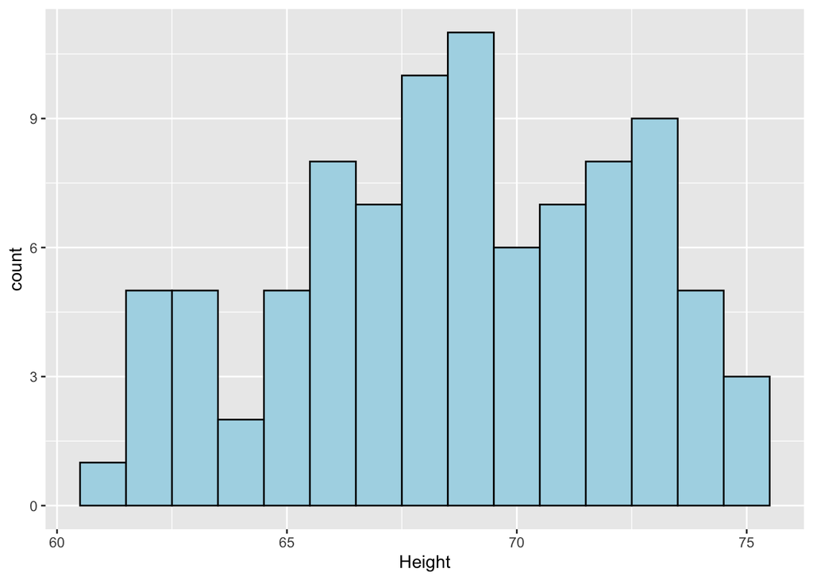

```r
ggplot(data1, aes(x=Height))+
  geom_histogram(binwidth=1,color="black", fill="lightblue")
```

We can also present the histograms of Heights for Male and Female students in the same graph with different colors. We define a function “HistWithGroups”

```r
HistWithGroups <- function(data,xcol,xname,group,gname,bwidth){
  ggplot(data, aes(x=xcol,fill=group))+
    geom_histogram(aes(y=..density..),color="black",binwidth=bwidth,alpha=0.6, position="identity")+
    scale_y_continuous(labels=scales::percent_format())+
    xlab(xname)+
    scale_fill_discrete(name=gname)

}
```

Now, we use this function to plot the comparing histograms for Height with different Sex

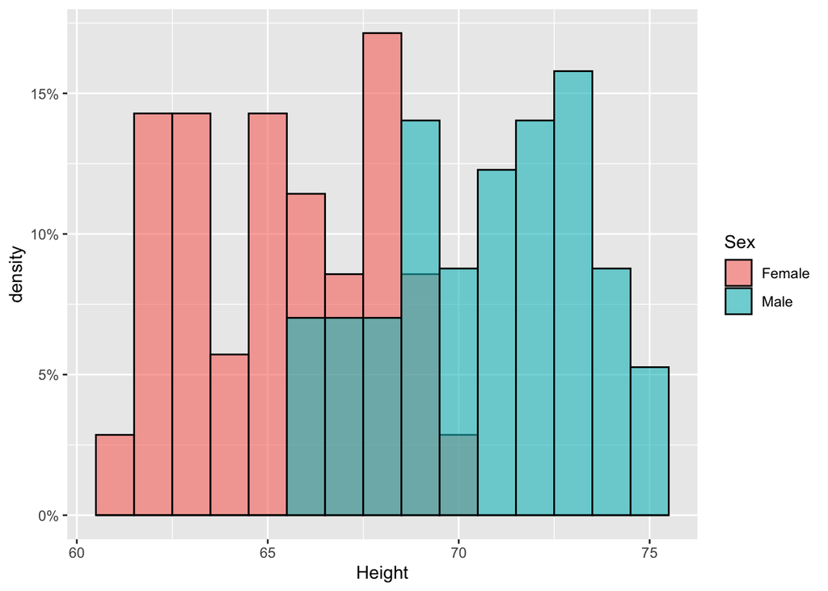

```r
HistWithGroups(data1,data1$Height,"Height",data1$Sex,"Sex",1)
```

## Assignment 4

Mimic the above codes, find the histogram of Weight for all students, and comparing histograms of Weight for Male and Female students. Please use binwidth=5 for the weight data.

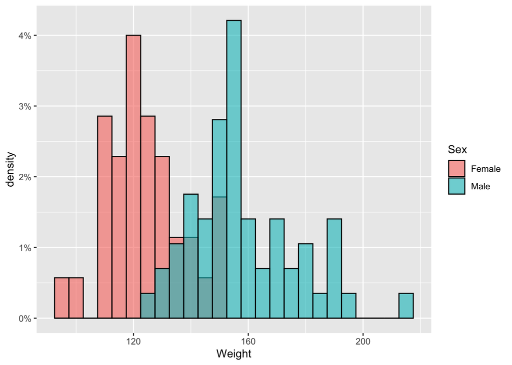

```r
HistWithGroups(data1,data1$Weight,"Weight",data1$Sex,"Sex",5)
```

**End of Assignment 4**

# Part III: Information from Summaries

Now, we can use the summaries we obtained above to answer the following questions:

```r
mean(Height)
```

```
## [1] 68.71739
```

```r
mean(Weight)
```

```
## [1] 145.1522
```

## Assignment 5

Answer the following questions:

1. What is the mean (average) height and weight of the Statistics Students?

   ```
   Height - [1] 68.71739
   Weight - [1] 145.1522
   ```

2. What is the mean (average) height and weight of the male and female Statistics Students?

   ```r
   mean(data1[data1$Sex == "Male",]$Height)
   ```

   ```
   ## [1] 70.75439
   ```

   ```r
   mean(data1[data1$Sex == "Male",]$Weight)
   ```

   ```
   ## [1] 158.2632
   ```

   ```r
   mean(data1[data1$Sex == "Female",]$Height)
   ```

   ```
   ## [1] 65.4
   ```

   ```r
   mean(data1[data1$Sex == "Female",]$Weight)
   ```

   ```
   ## [1] 123.8
   ```

3. What are the most frequent heights and weights of the students?

   ```r
   HeightCount <- data1 %>% group_by(Height) %>%
     summarise(Count=n())
   WeightCount <- data1 %>% group_by(Weight) %>%
     summarise(Count=n())

   HeightCount
   ```

   ```
   ## # A tibble: 21 × 2
   ##    Height Count
   ##     <dbl> <int>
   ##  1   61       1
   ##  2   61.8     1
   ##  3   62       4
   ##  4   62.8     1
   ##  5   63       4
   ##  6   64       2
   ##  7   65       4
   ##  8   65.5     1
   ##  9   66       8
   ## 10   67       7
   ## # ℹ 11 more rows
   ```

   ```r
   WeightCount
   ```

   ```
   ## # A tibble: 37 × 2
   ##    Weight Count
   ##     <int> <int>
   ##  1     95     1
   ##  2    102     1
   ##  3    108     2
   ##  4    110     2
   ##  5    112     1
   ##  6    115     2
   ##  7    116     2
   ##  8    118     2
   ##  9    120     3
   ## 10    121     1
   ## # ℹ 27 more rows
   ```

4. How many students have these heights and weights?

5. What are the most frequent heights and weights of the Female students, and how many female students have these heights and weights?

   ```r
   HeightCount <- subset(data1, Sex == 'Female') %>% group_by(Sex, Height) %>%
     summarise(Count=n())

   WeightCount <- subset(data1, Sex == 'Female') %>% group_by(Sex, Weight) %>%
     summarise(Count=n())


   HeightCount
   ```

   ```
   ## # A tibble: 13 × 3
   ## # Groups:   Sex [1]
   ##    Sex    Height Count
   ##    <chr>   <dbl> <int>
   ##  1 Female   61       1
   ##  2 Female   61.8     1
   ##  3 Female   62       4
   ##  4 Female   62.8     1
   ##  5 Female   63       4
   ##  6 Female   64       2
   ##  7 Female   65       4
   ##  8 Female   65.5     1
   ##  9 Female   66       4
   ## 10 Female   67       3
   ## 11 Female   68       6
   ## 12 Female   69       3
   ## 13 Female   70       1
   ```

   ```r
   WeightCount
   ```

   ```
   ## # A tibble: 20 × 3
   ## # Groups:   Sex [1]
   ##    Sex    Weight Count
   ##    <chr>   <int> <int>
   ##  1 Female     95     1
   ##  2 Female    102     1
   ##  3 Female    108     2
   ##  4 Female    110     2
   ##  5 Female    112     1
   ##  6 Female    115     2
   ##  7 Female    116     2
   ##  8 Female    118     2
   ##  9 Female    120     3
   ## 10 Female    121     1
   ## 11 Female    122     1
   ## 12 Female    125     5
   ## 13 Female    130     3
   ## 14 Female    131     1
   ## 15 Female    133     1
   ## 16 Female    135     1
   ## 17 Female    138     1
   ## 18 Female    140     1
   ## 19 Female    145     1
   ## 20 Female    150     3
   ```

6. By looking at the histogram what can be said about the heights and weights of the students? Does this agree with the results you found from the frequency tables?

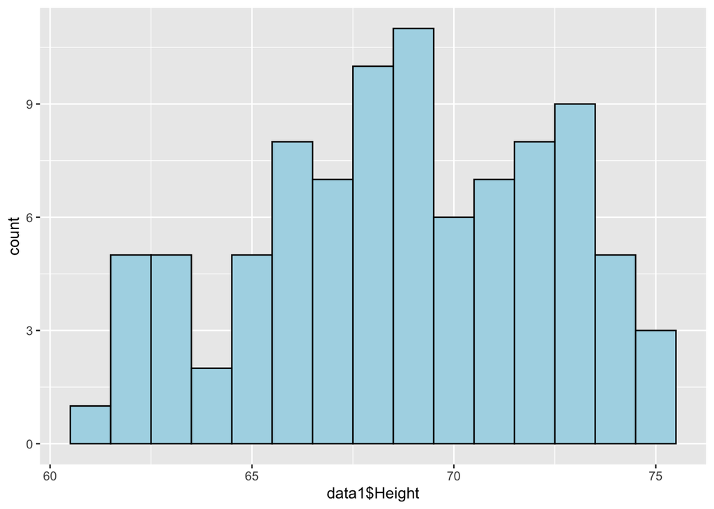

   ```r
   ggplot(data1, aes(x=data1$Height))+
     geom_histogram(binwidth=1,color="black", fill="lightblue")
   ```

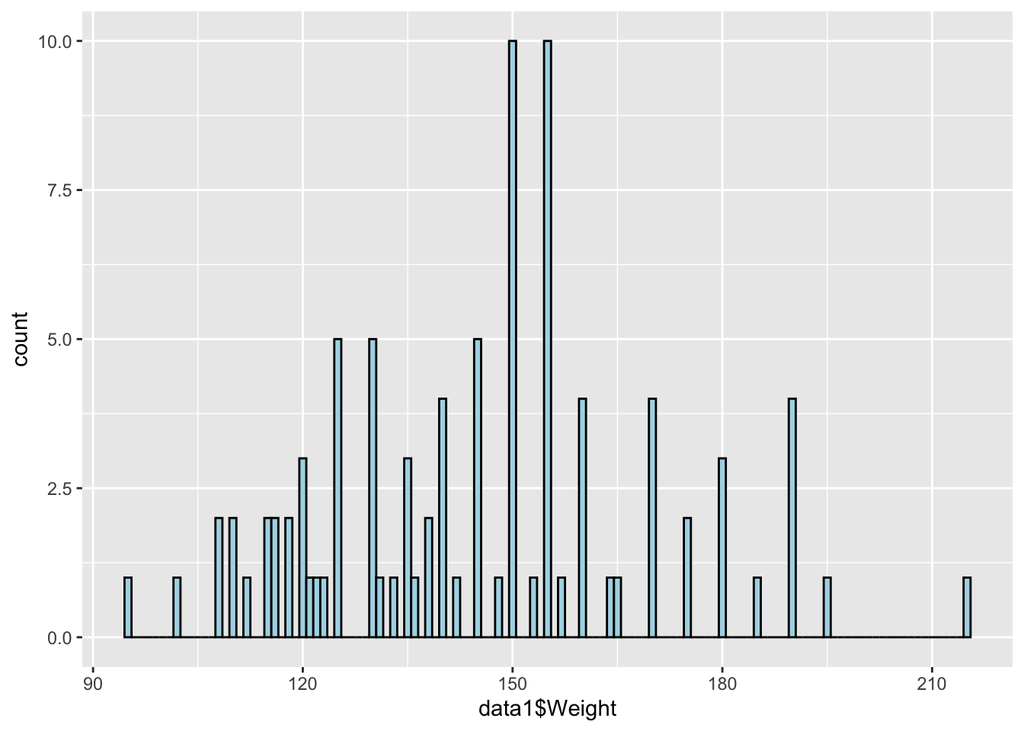

   ```r
   ggplot(data1, aes(x=data1$Weight))+
     geom_histogram(binwidth=1,color="black", fill="lightblue")
   ```

   ```r
   Weight
   ```

   ```
   ##  [1] 140 145 160 190 155 165 150 190 195 138 160 155 153 145 170 175 175 170 180
   ## [20] 135 170 157 130 185 140 120 130 138 121 125 116 145 150 112 125 190 155 170
   ## [39] 155 215 150 145 155 155 150 155 150 180 160 135 160 130 155 150 148 155 150
   ## [58] 140 180 190 145 150 164 140 142 136 123 155 130 120 130 131 120 118 125 135
   ## [77] 125 118 122 115 102 115 150 110 116 108  95 125 133 110 150 108
   ```

   ```
   It shows that around the median of heights and weights there is a higher count students at that height and weight.
   ```

7. By looking at the histograms, what can be said about the heights and weights of females and males?

   ```
   It shows that a lot of males are taller and heavier than the tallest and heaviest female. This agrees with what I found because the average hieghts and weights of females are lower than the average for males.
   ```

**End of Assignment 5**